# Praca domowa 2

Maciej Winkler

## Dane

Dane wykorzystane w Pracy domowej 2 opisują wycenę nieruchmości. Każda obserwacja jest pewną nieruchmością, która posiada informacje takie jak powierzchnia, liczba pokoi, liczba łazienek i wiele więcj. Opis wszystkich kolumn w pliku `README.md`.

## Zadanie 1

Jak wygląda rozkład ceny nieruchomości w poszczególnych kodach pocztowych na przestrzeni lat? Rozważamy kody pocztowe, które mają więcej niż 280 posiadłości.

```r
# Tu umieść kod do wygenerowania odpowiedzi do zadania.

library(scales) #wczytujemy bibliotekę scales dla wyraźniejszego odczytywania wykresu
```

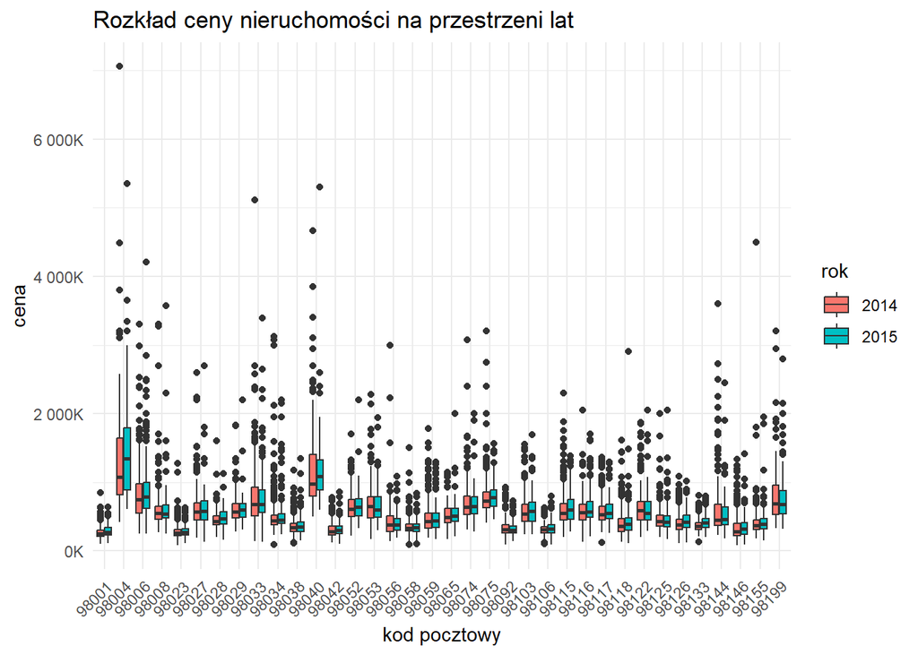

```r
result01 <- df %>%
  mutate(date = as.Date(date, format = "%Y%m%dT%H%M%S"),
         year = format(date, "%Y")) %>%
  group_by(zipcode) %>%
  filter(n() > 280) %>%
  ggplot(aes(x = factor(zipcode), y = price, fill = factor(year))) +
  geom_boxplot() +
  labs(title = "Rozkład ceny nieruchomości na przestrzeni lat",
       x = "kod pocztowy", y = "cena",
       fill = "rok") +
  scale_y_continuous(labels = label_number(scale = 1e-3, suffix = "K")) + #dla jaśniejszego przedstawienia cen K = 1000
  theme_minimal() +
  theme(axis.text.x = element_text(angle = 45, hjust = 1))
result01
```

**Komentarz:** #Rozkład cen został ukazany na wykresie pudełkowym stworzonym powyżej. Można zauważyć, #że ceny były nieco wyższe w roku 2015 dla większości mieszkań o konkretnych kodach pocztowych.

## Zadanie 2

Czy jest różnica w rozkładzie ceny nierchomości od powierzchni mieszkalnej uwzględniając podział na nieruchomości z piwnicą i bez?

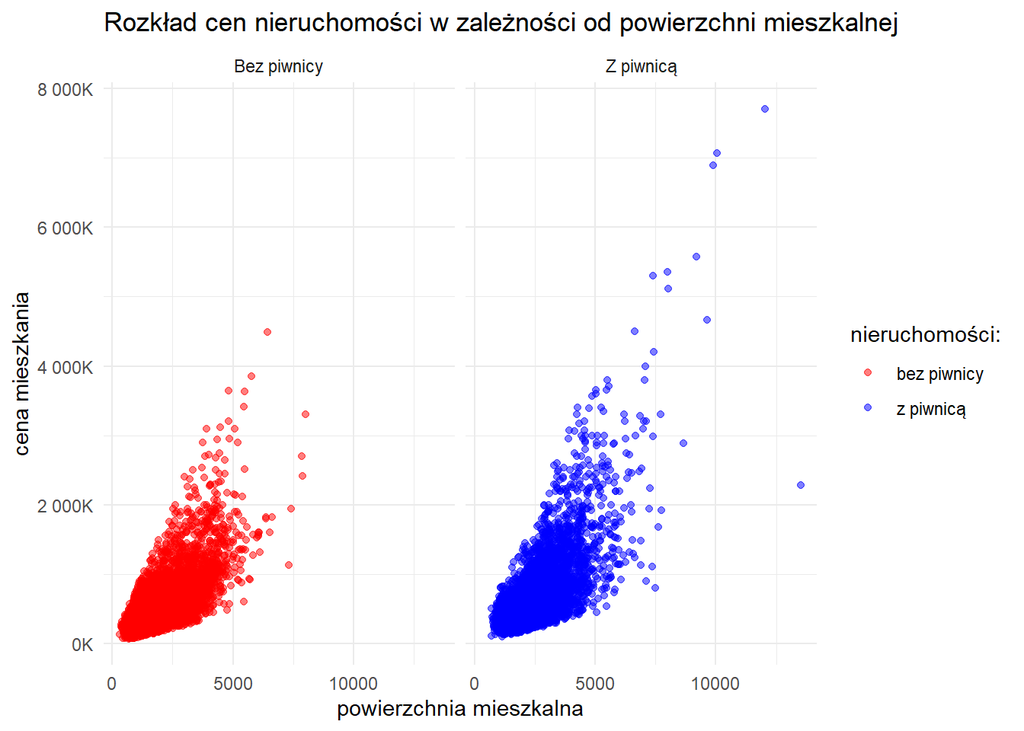

```r
# Tu umieść kod do wygenerowania odpowiedzi do zadania.

result02 <- df %>%
  select(id, price, sqft_living, sqft_basement) %>%
  ggplot(aes(x = sqft_living, y = price, color = factor(sqft_basement > 0))) +
  geom_point(alpha = 0.5) +
  labs(
    title = 'Rozkład cen nieruchomości w zależności od powierzchni mieszkalnej',
    x = 'powierzchnia mieszkalna',
    y = 'cena mieszkania',
    color = 'nieruchomości:'
  ) +
  scale_color_manual(
    values = c("TRUE" = "blue", "FALSE" = "red"),
    labels = c("TRUE" = "z piwnicą", "FALSE" = "bez piwnicy")
  ) +
  scale_y_continuous(labels = scales::label_number(scale = 1e-3, suffix = "K")) +
  theme_minimal() +
  facet_wrap(~ factor(sqft_basement > 0), labeller = labeller(`factor(sqft_basement > 0)` = c("TRUE" = "Z piwnicą", "FALSE" = "Bez piwnicy")))
result02
```

**Komentarz:** #Z powyżej skonstruowanego wykresu możemy zauważyć, że rozkład cen nieruchomości od powierzchni mieszkalnej #nie różni się zbytnio między nieruchomościami z piwnicą a tymi bez piwnicy.

## Zadanie 3

Jaka jest zależność pomiędzy jakością wykończenia nieruchomości a liczbą pięter?

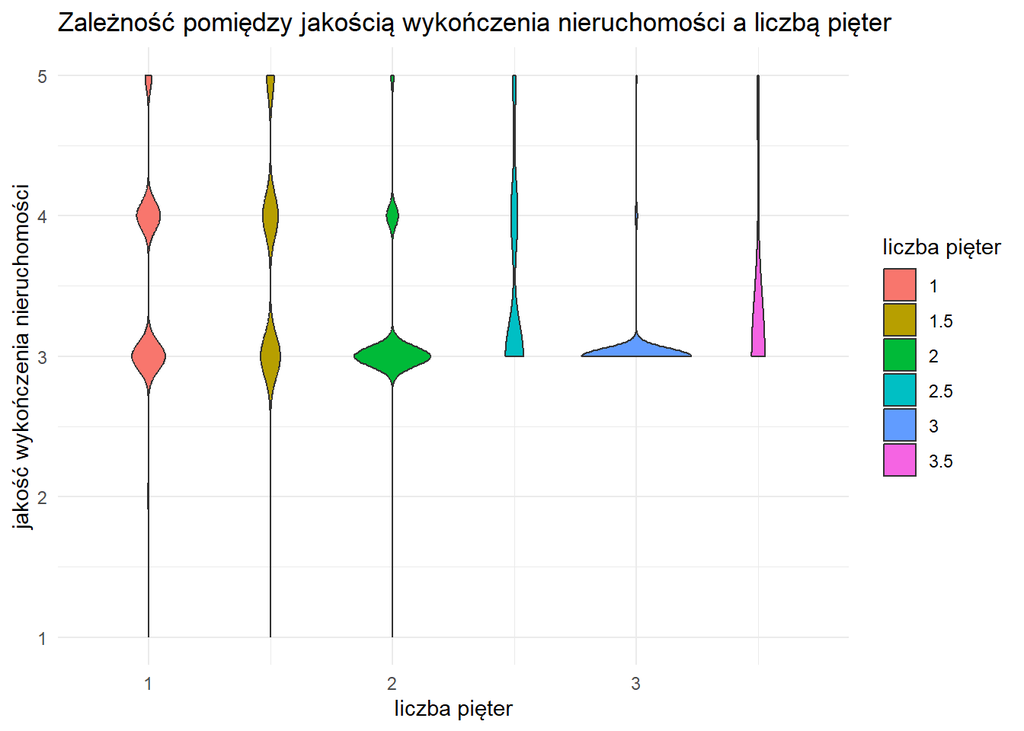

```r
# Tu umieść kod do wygenerowania odpowiedzi do zadania.

result03 <- df %>%
  select(id, condition, floors) %>%
  unique() %>% #pozbywamy się powtórzeń pewnych mieszkań
  ggplot(aes(x = floors, y = condition, fill = factor(floors)))+
  geom_violin()+
  labs(title = 'Zależność pomiędzy jakością wykończenia nieruchomości a liczbą pięter',
       x = 'liczba pięter',
       y = 'jakość wykończenia nieruchomości',
       fill = 'liczba pięter') +
  theme_minimal()
result03
```

## Zadanie 4 Jaka jest zależność między powierzchnią mieszkalną nieruchomości a powierzchnią gruntu w podziale na liczbę sypialni?

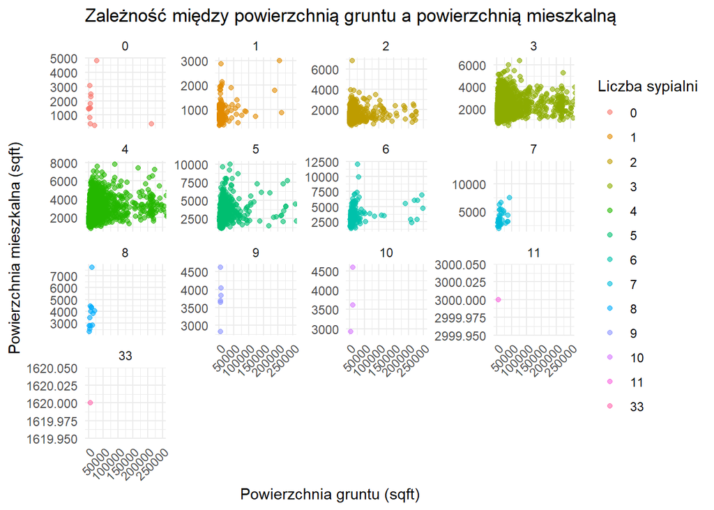

```r
# Tu umieść kod do wygenerowania odpowiedzi do zadania.

result04 <- df %>%
  select(id, sqft_living, sqft_lot, bedrooms) %>%
  unique() %>%  # Usunięcie powtórzeń mieszkań
  ggplot(aes(x = sqft_lot, y = sqft_living, color = factor(bedrooms))) +
  geom_point(alpha = 0.6) +
  coord_cartesian(xlim = c(0, 250000)) +
  labs(
    title = "Zależność między powierzchnią gruntu a powierzchnią mieszkalną",
    x = "Powierzchnia gruntu (sqft)",
    y = "Powierzchnia mieszkalna (sqft)",
    color = "Liczba sypialni"
  ) +
  theme_minimal() +
  theme(axis.text.x = element_text(angle = 45, hjust = 1)) +
  facet_wrap(~ bedrooms, scales = "free_y")
result04
```

**Komentarz:** #Wykres utworzony powyżej pokazuje, że duża powierzchnia mieszkalna zależy zazwyczaj od małej powierzchni mieszkalnej. #Jednak nie jest to prawda dla wszystkich przypadków.

## Zadanie 5 Rozważmy tylko nieruchomości, które miały remont. W której dekadzie było najwięcej przeprowadzonych remontów? Czy w poszczególnych dekadach jest porównywalny procent nieruchmości dla każdej wartości miary jakości i wykończenia nieruchomości?

```r
# Tu umieść kod do wygenerowania odpowiedzi do zadania.

dfx <- df %>% #Tworzymy ramkę pomocnicząm której użyjemy do znalezienia odpowiedzi na pytanie oraz stworzenia wykresu.
  select(id, yr_renovated, grade) %>%
  filter(yr_renovated != 0) %>%
  mutate(decade = floor(yr_renovated / 10) * 10)

dfy <- dfx %>% #Odpowiedź do pytania "W której dekadzie było najwięcej przeprowadzonych remontów?"
  group_by(decade) %>%
  summarise(dec_renov = n()) %>%
  filter(dec_renov == max(dec_renov))
dfy #Wywołując ramkę danych dfy możemy się przekonać że to w dekadzie 2000 - 2010 było najwięcej przeprowadzonych remontów - 272.
```

```
## # A tibble: 1 × 2
##   decade dec_renov
##    <dbl>     <int>
## 1   2000       272
```

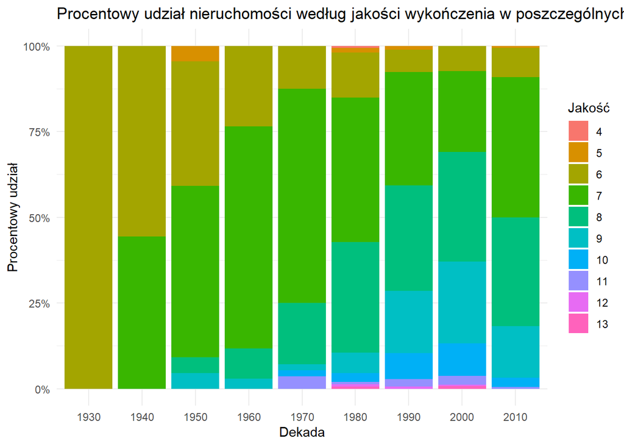

```r
result05 <- dfx %>%
  group_by(decade, grade) %>%
  summarise(count = n()) %>%
  ungroup() %>%
  group_by(decade) %>%
  mutate(percentage = count / sum(count)) %>%
  ggplot(aes(x = factor(decade), y = percentage, fill = factor(grade))) +
  geom_bar(stat = "identity", position = "fill") +
  labs(
    title = "Procentowy udział nieruchomości według jakości wykończenia w poszczególnych dekadach",
    x = "Dekada",
    y = "Procentowy udział",
    fill = "Jakość"
  ) +
  scale_y_continuous(labels = scales::percent) +
  theme_minimal()
result05
```

## Zadanie 6

Jak prezentuje się wartość minimalna, średnia i maksymalna ceny nieruchmości w podziele na rok budowy nieruchomości.

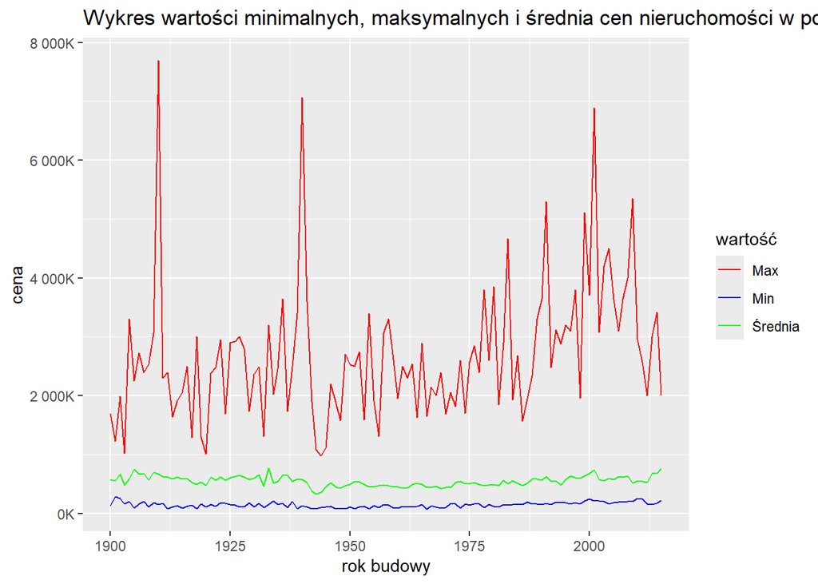

```r
# Tu umieść kod do wygenerowania odpowiedzi do zadania.

result06 <- df %>%
  select(id, price, yr_built) %>%
  unique() %>%
  group_by(yr_built) %>%
  summarise(min = min(price), max = max(price), mean = mean(price)) %>%
  ggplot(aes(x = yr_built, y = price)) +
  labs(title = 'Wykres wartości minimalnych, maksymalnych i średnia cen nieruchomości w podziele na rok budowy',
       x = 'rok budowy',
       y = 'cena',
       color = 'wartość') +
  geom_line(aes(y = min, color = "Min")) +
  geom_line(aes(y = max, color = "Max")) +
  geom_line(aes(y = mean, color = "Średnia")) +
  scale_y_continuous(labels = scales::label_number(scale = 1e-3, suffix = "K")) +
  scale_color_manual(values = c("Min" = "blue", "Max" = "red", "Średnia" = "green"))
result06
```

**Komentarz:** #Wartości minimalne, maksymalne oraz wartość średnia zostały ukazane na wykresie stworzonym powyżej. #Można zauważyć, że wartości naksymalne cen nieruchomości z poszczególnych lat budowy drastycznie się zwiększają #lub zmniejszają w kolejnych latach, za to wartości minimalne oraz średnie utrzymują podobną wartość we wszystkich latach.